# 1 - Basic Query Statements

George Melrose

2024-05-20

The concepts outlined by the SQL code below are taken from this LinkedIn learning course, *“SQL Server Fundamentals: Master Basic Query Techniques”* - www.linkedin.com/learning/sql-server-fundamentals-master-basic-query-techniques

## 1.Single Table ‘Select’ Statements

### All Columns

Gathering all columns from a table.

```sql
SELECT * FROM university ;
```

Displaying records 1 - 5

| id | country_id | university_name |
| --- | --- | --- |
| 1 | 73 | Harvard University |
| 2 | 73 | Massachusetts Institute of Technology |
| 3 | 73 | Stanford University |
| 4 | 72 | University of Cambridge |
| 5 | 73 | California Institute of Technology |

### Some Columns

Gathering selected columns from a table.

```sql
SELECT university_id, year, num_students FROM university_year;
```

Displaying records 1 - 5

| university_id | year | num_students |
| --- | --- | --- |
| 1 | 2011 | 20152 |
| 5 | 2011 | 2243 |
| 2 | 2011 | 11074 |
| 3 | 2011 | 15596 |
| 6 | 2011 | 7929 |

### Selecting the top results

```sql
SELECT university_id, year, num_students
FROM university_year
ORDER BY num_students DESC
LIMIT 3;
```

3 records

| university_id | year | num_students |
| --- | --- | --- |
| 952 | 2011 | 127431 |
| 80 | 2011 | 83236 |
| 80 | 2012 | 83236 |

### Changing results’ column headers

```sql
SELECT university_id[University ID], year[Year], num_students[No.Students]
FROM university_year
ORDER BY num_students DESC
LIMIT 3;
```

3 records

| University ID | Year | No.Students |
| --- | --- | --- |
| 952 | 2011 | 127431 |
| 80 | 2011 | 83236 |
| 80 | 2012 | 83236 |

## 2.Filtering on Single Conditions

### Finding rows fulfilling a condition

```sql
SELECT university_id[University ID], year[Year], num_students[No.Students]
FROM university_year
WHERE year = '2014';
```

Displaying records 1 - 5

| University ID | Year | No.Students |
| --- | --- | --- |
| 5 | 2014 | 2243 |
| 1 | 2014 | 20152 |
| 7 | 2014 | 19919 |
| 3 | 2014 | 15596 |
| 2 | 2014 | 11074 |

```sql
SELECT university_id[University ID], year[Year], num_students[No.Students]
FROM university_year
WHERE year != '2014';
```

Displaying records 1 - 5

| University ID | Year | No.Students |
| --- | --- | --- |
| 1 | 2011 | 20152 |
| 5 | 2011 | 2243 |
| 2 | 2011 | 11074 |
| 3 | 2011 | 15596 |
| 6 | 2011 | 7929 |

Note that != & <> are synonymous they both mean - not equal to.

```sql
SELECT university_id[University ID], year[Year], num_students[No.Students]
FROM university_year
WHERE year <> '2014';
```

Displaying records 1 - 5

| University ID | Year | No.Students |
| --- | --- | --- |
| 1 | 2011 | 20152 |
| 5 | 2011 | 2243 |
| 2 | 2011 | 11074 |
| 3 | 2011 | 15596 |
| 6 | 2011 | 7929 |

### Finding rows fufilling a list

```sql
SELECT country_name[Country]
FROM country
WHERE country_name IN ('Belarus','Ukraine','Russia');
```

3 records

| Country |
| --- |
| Belarus |
| Russia |
| Ukraine |

### Finding rows not fufilling a list

```sql
SELECT country_name[Country]
FROM country
WHERE country_name NOT IN ('Belarus','Ukraine','Russia');
```

Displaying records 1 - 5

| Country |
| --- |
| Argentina |
| Australia |
| Austria |
| Bangladesh |
| Belgium |

### Finding rows starting and ending with certain characters/a string

```sql
SELECT country_name[Country]
FROM country
WHERE country_name LIKE 'Un%';
```

3 records

| Country |
| --- |
| United Arab Emirates |
| United Kingdom |
| United States of America |

```sql
SELECT country_name[Country]
FROM country
WHERE country_name NOT LIKE 'Un%';
```

Displaying records 1 - 5

| Country |
| --- |
| Argentina |
| Australia |
| Austria |
| Bangladesh |
| Belarus |

```sql
SELECT country_name[Country]
FROM country
WHERE country_name LIKE '%land';
```

Displaying records 1 - 5

| Country |
| --- |
| Finland |
| Iceland |
| Ireland |
| New Zealand |
| Poland |

```sql
SELECT country_name[Country]
FROM country
WHERE country_name NOT LIKE '%sia';
```

Displaying records 1 - 5

| Country |
| --- |
| Argentina |
| Australia |
| Austria |
| Bangladesh |
| Belarus |

### Finding rows containing a string

```sql
SELECT country_name[Country]
FROM country
WHERE country_name LIKE '%United%';
```

3 records

| Country |
| --- |
| United Arab Emirates |
| United Kingdom |
| United States of America |

### Finding rows based off of numerical parameters

```sql
SELECT *
FROM university_year
WHERE pct_female_students between 50 and 60
```

Displaying records 1 - 5

| university_id | year | num_students | student_staff_ratio | pct_international_students | pct_female_students |
| --- | --- | --- | --- | --- | --- |
| 10 | 2011 | 36186 | 16.4 | 15 | 50 |
| 8 | 2011 | 11751 | 4.4 | 20 | 50 |
| 19 | 2011 | 38206 | 10.3 | 15 | 52 |
| 15 | 2011 | 15128 | 3.6 | 23 | 50 |
| 13 | 2011 | 20376 | 6.5 | 20 | 51 |

```sql
SELECT *
FROM university_year
WHERE pct_international_students <50
```

Displaying records 1 - 5

| university_id | year | num_students | student_staff_ratio | pct_international_students | pct_female_students |
| --- | --- | --- | --- | --- | --- |
| 1 | 2011 | 20152 | 8.9 | 25 | NA |
| 5 | 2011 | 2243 | 6.9 | 27 | 33 |
| 2 | 2011 | 11074 | 9.0 | 33 | 37 |
| 3 | 2011 | 15596 | 7.8 | 22 | 42 |
| 6 | 2011 | 7929 | 8.4 | 27 | 45 |

```sql
SELECT *
FROM university_year
WHERE pct_international_students >= 50
```

Displaying records 1 - 5

| university_id | year | num_students | student_staff_ratio | pct_international_students | pct_female_students |
| --- | --- | --- | --- | --- | --- |
| 28 | 2011 | 15060 | 11.7 | 51 | 37 |
| 1032 | 2011 | 9666 | 10.5 | 54 | 27 |
| 28 | 2012 | 15060 | 11.7 | 51 | 37 |
| 1032 | 2012 | 9666 | 10.5 | 54 | 27 |
| 28 | 2013 | 15060 | 11.7 | 51 | 37 |

```sql
SELECT *
FROM university_year
WHERE pct_international_students > 50
```

Displaying records 1 - 5

| university_id | year | num_students | student_staff_ratio | pct_international_students | pct_female_students |
| --- | --- | --- | --- | --- | --- |
| 28 | 2011 | 15060 | 11.7 | 51 | 37 |
| 1032 | 2011 | 9666 | 10.5 | 54 | 27 |
| 28 | 2012 | 15060 | 11.7 | 51 | 37 |
| 1032 | 2012 | 9666 | 10.5 | 54 | 27 |
| 28 | 2013 | 15060 | 11.7 | 51 | 37 |

```sql
SELECT *
FROM university_year
WHERE pct_international_students IS NULL
```

0 records

| university_id | year | num_students | student_staff_ratio | pct_international_students | pct_female_students |
| --- | --- | --- | --- | --- | --- |

```sql
SELECT *
FROM university_year
WHERE pct_international_students IS NOT NULL
```

Displaying records 1 - 5

| university_id | year | num_students | student_staff_ratio | pct_international_students | pct_female_students |
| --- | --- | --- | --- | --- | --- |
| 1 | 2011 | 20152 | 8.9 | 25 | NA |
| 5 | 2011 | 2243 | 6.9 | 27 | 33 |
| 2 | 2011 | 11074 | 9.0 | 33 | 37 |
| 3 | 2011 | 15596 | 7.8 | 22 | 42 |
| 6 | 2011 | 7929 | 8.4 | 27 | 45 |

## 3.Filtering on Multiple Conditions

```sql
SELECT *
FROM university_year
WHERE pct_international_students >30 AND pct_female_students >50 AND year = 2012
```

Displaying records 1 - 5

| university_id | year | num_students | student_staff_ratio | pct_international_students | pct_female_students |
| --- | --- | --- | --- | --- | --- |
| 31 | 2012 | 26607 | 10.7 | 46 | 56 |
| 158 | 2012 | 19835 | 17.6 | 38 | 53 |
| 60 | 2012 | 25774 | 14.1 | 36 | 58 |
| 118 | 2012 | 40128 | 23.7 | 35 | 55 |
| 107 | 2012 | 14604 | 19.2 | 35 | 52 |

```sql
SELECT *
FROM university_year
WHERE pct_international_students >30 AND pct_female_students >50 AND year = 2012
```

Displaying records 1 - 5

| university_id | year | num_students | student_staff_ratio | pct_international_students | pct_female_students |
| --- | --- | --- | --- | --- | --- |
| 31 | 2012 | 26607 | 10.7 | 46 | 56 |
| 158 | 2012 | 19835 | 17.6 | 38 | 53 |
| 60 | 2012 | 25774 | 14.1 | 36 | 58 |
| 118 | 2012 | 40128 | 23.7 | 35 | 55 |
| 107 | 2012 | 14604 | 19.2 | 35 | 52 |

```sql
SELECT *
FROM university
WHERE university_name LIKE '%London%' or university_name LIKE '%Paris%' OR university_name LIKE '%Glasgow'
```

Displaying records 1 - 5

| id | country_id | university_name |
| --- | --- | --- |
| 28 | 72 | Imperial College London |
| 31 | 72 | University College London |
| 48 | 20 | University of Paris-Sud |
| 54 | 20 | École normale supérieure - Paris |
| 100 | 20 | Mines ParisTech |

## 4.Inner Joins

Necessary, compared to a subquery, if you need to reference columns needed from filtering, like the name of a University below.

```r
knitr::include_graphics("C:/Users/gam55/Downloads/universities_erd.png")
```

[output not shown]

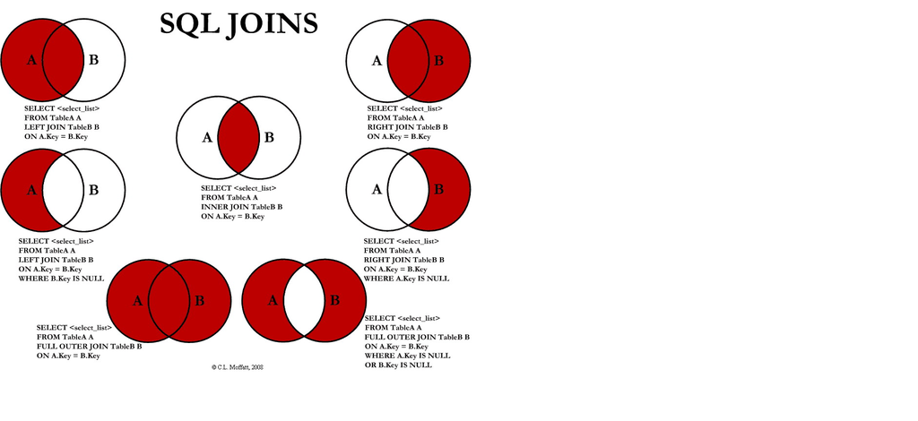

```r
knitr::include_graphics("C:/Users/gam55/Downloads/joins.png")
```

### Single Join

```sql
SELECT *
FROM university u
INNER JOIN university_year y
ON u.id = y.university_id
WHERE university_name = 'Imperial College London' OR university_name = 'University of Glasgow'
```

Displaying records 1 - 10

| id | country_id | university_name | university_id | year | num_students | student_staff_ratio | pct_international_students | pct_female_students |
| --- | --- | --- | --- | --- | --- | --- | --- | --- |
| 28 | 72 | Imperial College London | 28 | 2011 | 15060 | 11.7 | 51 | 37 |
| 28 | 72 | Imperial College London | 28 | 2012 | 15060 | 11.7 | 51 | 37 |
| 28 | 72 | Imperial College London | 28 | 2013 | 15060 | 11.7 | 51 | 37 |
| 28 | 72 | Imperial College London | 28 | 2014 | 15060 | 11.7 | 51 | 37 |
| 28 | 72 | Imperial College London | 28 | 2015 | 15060 | 11.7 | 51 | 37 |
| 28 | 72 | Imperial College London | 28 | 2016 | 15060 | 11.7 | 51 | 37 |
| 142 | 72 | University of Glasgow | 142 | 2011 | 22616 | 16.0 | 29 | 57 |
| 142 | 72 | University of Glasgow | 142 | 2012 | 22616 | 16.0 | 29 | 57 |
| 142 | 72 | University of Glasgow | 142 | 2013 | 22616 | 16.0 | 29 | 57 |
| 142 | 72 | University of Glasgow | 142 | 2014 | 22616 | 16.0 | 29 | 57 |

### Multiple Joins

```sql
SELECT *
FROM university u
INNER JOIN university_year y
ON u.id = y.university_id
INNER JOIN country c
ON u.country_id = c.id
WHERE c.country_name = 'United Kingdom' AND u.university_name = 'University of Cambridge'
```

6 records

| id | country_id | university_name | university_id | year | num_students | student_staff_ratio | pct_international_students | pct_female_students | id | country_name |
| --- | --- | --- | --- | --- | --- | --- | --- | --- | --- | --- |
| 4 | 72 | University of Cambridge | 4 | 2011 | 18812 | 11.8 | 34 | 46 | 72 | United Kingdom |
| 4 | 72 | University of Cambridge | 4 | 2012 | 18812 | 11.8 | 34 | 46 | 72 | United Kingdom |
| 4 | 72 | University of Cambridge | 4 | 2013 | 18812 | 11.8 | 34 | 46 | 72 | United Kingdom |
| 4 | 72 | University of Cambridge | 4 | 2014 | 18812 | 11.8 | 34 | 46 | 72 | United Kingdom |
| 4 | 72 | University of Cambridge | 4 | 2015 | 18812 | 11.8 | 34 | 46 | 72 | United Kingdom |
| 4 | 72 | University of Cambridge | 4 | 2016 | 18812 | 11.8 | 34 | 46 | 72 | United Kingdom |

## 5.Outer Joins

### Left Outer Join

```sql
SELECT u.university_name, y.year, y.num_students, y.pct_international_students
FROM university_year y
LEFT OUTER JOIN university u
ON u.id = y.university_id
WHERE university_name = 'University of St Andrews'
```

6 records

| university_name | year | num_students | pct_international_students |
| --- | --- | --- | --- |
| University of St Andrews | 2011 | 8338 | 47 |
| University of St Andrews | 2012 | 8338 | 47 |
| University of St Andrews | 2013 | 8338 | 47 |
| University of St Andrews | 2014 | 8338 | 47 |
| University of St Andrews | 2015 | 8338 | 47 |
| University of St Andrews | 2016 | 8338 | 47 |

```sql
SELECT u.university_name, y.year, y.num_students, y.pct_international_students
FROM university_year y
LEFT OUTER JOIN university u
ON u.id = y.university_id
WHERE y.num_students < 10000
```

Displaying records 1 - 10

| university_name | year | num_students | pct_international_students |
| --- | --- | --- | --- |
| California Institute of Technology | 2011 | 2243 | 27 |
| Princeton University | 2011 | 7929 | 27 |
| Pohang University of Science and Technology | 2011 | 3055 | 4 |
| École Polytechnique | 2011 | 2429 | 30 |
| École Normale Supérieure | 2011 | 2400 | 20 |
| Rice University | 2011 | 6333 | 26 |
| École Polytechnique Fédérale de Lausanne | 2011 | 9666 | 54 |
| Brown University | 2011 | 8653 | 19 |
| Case Western Reserve University | 2011 | 9259 | 17 |
| Yeshiva University | 2011 | 6753 | 7 |

## 6.Subqueries

Can only be used when you don’t need to return columns from the subquery tables - we don’t need to see the number of students below.

Can sometimes be better for filtering than INNER JOINs.

```sql
SELECT score, ranking_criteria_id, university_id
FROM university_ranking_year
WHERE university_id
IN (SELECT university_id
FROM university_year WHERE num_students < 10000
)
ORDER BY score DESC
```

Displaying records 1 - 10

| score | ranking_criteria_id | university_id |
| --- | --- | --- |
| 980 | 17 | 100 |
| 977 | 17 | 100 |
| 973 | 17 | 854 |
| 959 | 17 | 854 |
| 950 | 18 | 792 |
| 897 | 18 | 792 |
| 871 | 20 | 100 |
| 871 | 20 | 384 |
| 871 | 20 | 625 |
| 871 | 20 | 792 |

## 7.Case Statements

There are times when you want to present the data differently than in the way it’s available to you in your table, or you might want to show different texts depending on the data state. And that’s where case statements come in.

First is a scalar variable, which is declared and then named with the @ symbol at the front. Then SQL server is told, what kind of data is going to be held in this variable. In this case it is an *integer* type. A variable can be assigned to this variable.Divisible is a column alias.

A case statement is a conditional statement.

First, we declare that this is a case.

Then, when @number is divided by 2, the remainder is 0 - an even number.

When @number is divided by 3, the remainder is 0 - divisible by 3.

The percent sign here is called modulo - *“The modulo operator in SQL is typically represented by the % symbol, and it is used to return the remainder of a division operation.”*

The *else* isn’t strictly required but it’s good practice as otherwise the statement will return NULL.

The SQL code below from the LinkedIn learning course doesn’t work in RStudio - SQLite doesn’t support support variable declarations

“declare @number int = 5

SELECT divisible = case when @number % 2 = 0 then ‘divisible by 2’ when @number % 3 = 0 then ‘divisible by 3’ else ‘does not meet criteria’ end”

A more basic query is needed -

```sql
SELECT
    CASE
    WHEN 5 % 2 = 0 THEN 'divisible by 2'
    WHEN 5 % 3 = 0 THEN 'divisible by 3'
    ELSE 'does not meet criteria'
    END AS divisible
```

1 records

| divisible |
| --- |
| does not meet criteria |

```sql
SELECT DISTINCT
    u.university_name AS University,
    y.student_staff_ratio AS "Students:Staff",
    y.num_students AS "No.Students",
    y.pct_international_students AS "% International Students",
    y.pct_female_students AS "% Female Students",
    CASE
        WHEN y.num_students < 10000 THEN 'Small'
        WHEN y.num_students BETWEEN 10000 AND 20000 THEN 'Medium'
        WHEN y.num_students > 20000 THEN 'Large'
        ELSE 'NA'
    END AS Size
FROM
    university u
INNER JOIN
    university_year y
ON
    u.id = y.university_id
ORDER BY y.pct_international_students DESC;
```

Displaying records 1 - 10

| University | Students:Staff | No.Students | % International Students | % Female Students | Size |
| --- | --- | --- | --- | --- | --- |
| École Polytechnique Fédérale de Lausanne | 10.5 | 9666 | 54 | 27 | Small |
| Imperial College London | 11.7 | 15060 | 51 | 37 | Medium |
| Maastricht University | 18.9 | 15626 | 48 | 56 | Medium |
| University of St Andrews | 12.7 | 8338 | 47 | 56 | Small |
| University College London | 10.7 | 26607 | 46 | 56 | Large |
| Queen Mary University of London | 14.0 | 14260 | 40 | 52 | Medium |
| University of Geneva | 15.0 | 15668 | 39 | 61 | Medium |
| University of Innsbruck | 16.9 | 18209 | 39 | 54 | Medium |
| University of Hong Kong | 17.6 | 19835 | 38 | 53 | Medium |
| Birkbeck, University of London | 17.2 | 9454 | 38 | 55 | Small |

## 8.Built-in Functions

```r
knitr::include_graphics("C:/Users/gam55/Downloads/universities_erd.png")
```

[output not shown]

The functions in this section just scratch the surface of the vast array of possible built-in SQL functions. More are found here - https://learn.microsoft.com/en-us/sql/t-sql/functions/functions?view=sql-server-ver15#scalar-functions

### CAST()

We can use CAST() to change the ‘data type’ of a column into something else, like numeric to integer. This is the same as using as.numeric() or as.factor() in R. Unfortunately, SQLite in RStudio doesn’t support the CONVERT() function.However, there is no direct support for specifying decimal precision in the CAST function. SQLite stores numeric values as REAL (floating-point) internally when they’re cast to numeric types.

```sql
SELECT DISTINCT
    u.university_name AS University,
    y.student_staff_ratio AS "Students:Staff",
    CAST(y.student_staff_ratio AS INT) AS "Students:Staff INT Cast",
    CAST(y.student_staff_ratio AS REAL) AS "Students:Staff Decimal Conversion",
    y.num_students AS "No.Students",
    y.pct_international_students AS "% International Students",
    y.pct_female_students AS "% Female Students",
    CASE
        WHEN y.num_students < 10000 THEN 'Small'
        WHEN y.num_students BETWEEN 10000 AND 20000 THEN 'Medium'
        WHEN y.num_students > 20000 THEN 'Large'
        ELSE 'NA'
    END AS Size
FROM
    university u
INNER JOIN
    university_year y
ON
    u.id = y.university_id
ORDER BY
    y.pct_international_students DESC;
```

Displaying records 1 - 10

| University | Students:Staff | Students:Staff INT Cast | Students:Staff Decimal Conversion | No.Students | % International Students | % Female Students | Size |
| --- | --- | --- | --- | --- | --- | --- | --- |
| École Polytechnique Fédérale de Lausanne | 10.5 | 10 | 10.5 | 9666 | 54 | 27 | Small |
| Imperial College London | 11.7 | 11 | 11.7 | 15060 | 51 | 37 | Medium |
| Maastricht University | 18.9 | 18 | 18.9 | 15626 | 48 | 56 | Medium |
| University of St Andrews | 12.7 | 12 | 12.7 | 8338 | 47 | 56 | Small |
| University College London | 10.7 | 10 | 10.7 | 26607 | 46 | 56 | Large |
| Queen Mary University of London | 14.0 | 14 | 14.0 | 14260 | 40 | 52 | Medium |
| University of Geneva | 15.0 | 15 | 15.0 | 15668 | 39 | 61 | Medium |
| University of Innsbruck | 16.9 | 16 | 16.9 | 18209 | 39 | 54 | Medium |
| University of Hong Kong | 17.6 | 17 | 17.6 | 19835 | 38 | 53 | Medium |
| Birkbeck, University of London | 17.2 | 17 | 17.2 | 9454 | 38 | 55 | Small |

### CONCAT()

Below, the university name is concatenated with the number of students. CONCAT() usefully, can handle mixed data types.

```sql
SELECT DISTINCT
    u.university_name AS University,
    y.student_staff_ratio AS "Students:Staff",
    CAST(y.student_staff_ratio AS INT) AS "Students:Staff INT Cast",
    CAST(y.student_staff_ratio AS REAL) AS "Students:Staff Decimal Conversion",
    y.num_students AS "No.Students",
    y.pct_international_students AS "% International Students",
    y.pct_female_students AS "% Female Students",
    CASE
        WHEN y.num_students < 10000 THEN 'Small'
        WHEN y.num_students BETWEEN 10000 AND 20000 THEN 'Medium'
        WHEN y.num_students > 20000 THEN 'Large'
        ELSE 'NA'
    END AS Size,
    CONCAT(u.university_name, ' - ', y.num_students) AS "University and Students"
FROM
    university u
INNER JOIN
    university_year y
ON
    u.id = y.university_id
ORDER BY
    y.pct_international_students DESC;
```

Displaying records 1 - 10

| University | Students:Staff | Students:Staff INT Cast | Students:Staff Decimal Conversion | No.Students | % International Students | % Female Students | Size | University and Students |
| --- | --- | --- | --- | --- | --- | --- | --- | --- |
| École Polytechnique Fédérale de Lausanne | 10.5 | 10 | 10.5 | 9666 | 54 | 27 | Small | École Polytechnique Fédérale de Lausanne - 9666.0 |
| Imperial College London | 11.7 | 11 | 11.7 | 15060 | 51 | 37 | Medium | Imperial College London - 15060.0 |
| Maastricht University | 18.9 | 18 | 18.9 | 15626 | 48 | 56 | Medium | Maastricht University - 15626.0 |
| University of St Andrews | 12.7 | 12 | 12.7 | 8338 | 47 | 56 | Small | University of St Andrews - 8338.0 |
| University College London | 10.7 | 10 | 10.7 | 26607 | 46 | 56 | Large | University College London - 26607.0 |
| Queen Mary University of London | 14.0 | 14 | 14.0 | 14260 | 40 | 52 | Medium | Queen Mary University of London - 14260.0 |
| University of Geneva | 15.0 | 15 | 15.0 | 15668 | 39 | 61 | Medium | University of Geneva - 15668.0 |
| University of Innsbruck | 16.9 | 16 | 16.9 | 18209 | 39 | 54 | Medium | University of Innsbruck - 18209.0 |
| University of Hong Kong | 17.6 | 17 | 17.6 | 19835 | 38 | 53 | Medium | University of Hong Kong - 19835.0 |
| Birkbeck, University of London | 17.2 | 17 | 17.2 | 9454 | 38 | 55 | Small | Birkbeck, University of London - 9454.0 |

### FORMAT()/ printf()

FORMAT() can be used to format information likes dates and currencies.

SQLite does not have a built-in FORMAT() function like some other SQL databases (e.g. SQL Server). However, similar formatting can be achieved using other SQLite functions. For instance, the printf() function can be used to format numbers or strings.

```sql
SELECT DISTINCT
    u.university_name AS University,
    y.student_staff_ratio AS "Students:Staff",
    CAST(y.student_staff_ratio AS INT) AS "Students:Staff INT Cast",
    CAST(y.student_staff_ratio AS REAL) AS "Students:Staff Decimal Conversion",
    y.num_students AS "No.Students",
    y.pct_international_students AS "% International Students",
    y.pct_female_students AS "% Female Students",
    CASE
        WHEN y.num_students < 10000 THEN 'Small'
        WHEN y.num_students BETWEEN 10000 AND 20000 THEN 'Medium'
        WHEN y.num_students > 20000 THEN 'Large'
        ELSE 'NA'
    END AS Size,
    u.university_name || ' - ' || y.num_students AS "University and Students",
    printf('%.2f', y.student_staff_ratio) AS "Formatted Students:Staff"
FROM
    university u
INNER JOIN
    university_year y
ON
    u.id = y.university_id
ORDER BY
    y.pct_international_students DESC;
```

Displaying records 1 - 10

| University | Students:Staff | Students:Staff INT Cast | Students:Staff Decimal Conversion | No.Students | % International Students | % Female Students | Size | University and Students | Formatted Students:Staff |
| --- | --- | --- | --- | --- | --- | --- | --- | --- | --- |
| École Polytechnique Fédérale de Lausanne | 10.5 | 10 | 10.5 | 9666 | 54 | 27 | Small | École Polytechnique Fédérale de Lausanne - 9666.0 | 10.50 |
| Imperial College London | 11.7 | 11 | 11.7 | 15060 | 51 | 37 | Medium | Imperial College London - 15060.0 | 11.70 |
| Maastricht University | 18.9 | 18 | 18.9 | 15626 | 48 | 56 | Medium | Maastricht University - 15626.0 | 18.90 |
| University of St Andrews | 12.7 | 12 | 12.7 | 8338 | 47 | 56 | Small | University of St Andrews - 8338.0 | 12.70 |
| University College London | 10.7 | 10 | 10.7 | 26607 | 46 | 56 | Large | University College London - 26607.0 | 10.70 |
| Queen Mary University of London | 14.0 | 14 | 14.0 | 14260 | 40 | 52 | Medium | Queen Mary University of London - 14260.0 | 14.00 |
| University of Geneva | 15.0 | 15 | 15.0 | 15668 | 39 | 61 | Medium | University of Geneva - 15668.0 | 15.00 |
| University of Innsbruck | 16.9 | 16 | 16.9 | 18209 | 39 | 54 | Medium | University of Innsbruck - 18209.0 | 16.90 |
| University of Hong Kong | 17.6 | 17 | 17.6 | 19835 | 38 | 53 | Medium | University of Hong Kong - 19835.0 | 17.60 |
| Birkbeck, University of London | 17.2 | 17 | 17.2 | 9454 | 38 | 55 | Small | Birkbeck, University of London - 9454.0 | 17.20 |

### datetime(), date(), and strftime()

SQLite does not have a built-in DATEADD() function.. However, similar functionality can be achieved using SQLite’s date and time functions. Specifically, using the datetime(), date(), and strftime() functions with modifiers to add or subtract time intervals.

Adding Days - To add a certain number of days to a date, one can use the date() function with the ‘+N days’ modifier, where N is the number of days to be added:

**Adding Days**

```sql
SELECT date('now', '+7 days') AS "Date Plus 7 Days";
```

1 records

| Date Plus 7 Days |
| --- |
| 2024-05-31 |

**Adding Months**

```sql
SELECT date('now', '+1 month') AS "Date Plus 1 Month";
```

1 records

| Date Plus 1 Month |
| --- |
| 2024-06-24 |

**Adding Years**

```sql
SELECT date('now', '+1 year') AS "Date Plus 1 Year";
```

1 records

| Date Plus 1 Year |
| --- |
| 2025-05-24 |

**Adding Hours, Minutes, or Seconds**

This can be done using datetime()

```sql
SELECT datetime('now', '+2 hours') AS "Date Plus 2 Hours";
```

1 records

| Date Plus 2 Hours |
| --- |
| 2024-05-24 10:26:10 |

```sql
SELECT datetime('now', '+30 minutes') AS "Date Plus 30 Minutes";
```

1 records

| Date Plus 30 Minutes |
| --- |
| 2024-05-24 08:56:10 |

```sql
SELECT datetime('now', '+45 seconds') AS "Date Plus 45 Seconds";
```

1 records

| Date Plus 45 Seconds |
| --- |
| 2024-05-24 08:26:55 |

## 9.Aggregate Functions

```r
knitr::include_graphics("C:/Users/gam55/Downloads/universities_erd.png")
```

[output not shown]

SQL provides aggregate functions to do calculations across multiple rows to find a sum or an average.

Counting all the rows in a table.

```sql
select count(*)
from university
```

1 records

| count(*) |
| --- |
| 1247 |

Grouping variables together.

```sql
SELECT COUNT(*) AS "No.Universities", c.country_name AS "Country"
FROM country c
INNER JOIN university u ON u.country_id = c.id
GROUP BY c.country_name;
```

Displaying records 1 - 10

| No.Universities | Country |
| --- | --- |
| 4 | Argentina |
| 35 | Australia |
| 12 | Austria |
| 1 | Bangladesh |
| 1 | Belarus |
| 11 | Belgium |
| 27 | Brazil |
| 1 | Bulgaria |
| 37 | Canada |
| 7 | Chile |

Having a look at the rankings systems available.

```sql
SELECT rc.criteria_name AS "Criteria Name", COUNT(DISTINCT u.id) AS "No.Universities"
FROM university u
INNER JOIN university_ranking_year ry ON ry.university_id = u.id
INNER JOIN ranking_criteria rc ON ry.ranking_criteria_id = rc.id
GROUP BY rc.criteria_name
ORDER BY "No.Universities" DESC;
```

Displaying records 1 - 10

| Criteria Name | No.Universities |
| --- | --- |
| Total CWUR | 1024 |
| Quality of Faculty Rank | 1024 |
| Quality of Education Rank | 1024 |
| Publications Rank | 1024 |
| Patents Rank | 1024 |
| Influence Rank | 1024 |
| Citations Rank | 1024 |
| Alumni Employment Rank | 1024 |
| Total Times | 245 |
| Teaching | 245 |

Using the MAX() function to order Universities by their Times ranking.

```sql
SELECT u.university_name AS "University", MAX(ry.score) AS "Maximum Score"
FROM university u
INNER JOIN university_ranking_year ry ON ry.university_id = u.id
INNER JOIN ranking_criteria rc ON ry.ranking_criteria_id = rc.id
WHERE rc.criteria_name = 'Total Times'
GROUP BY u.university_name
ORDER BY "Maximum Score" DESC;
```

Displaying records 1 - 20

| University | Maximum Score |
| --- | --- |
| Massachusetts Institute of Technology | 96 |
| Harvard University | 96 |
| California Institute of Technology | 96 |
| University of Oxford | 94 |
| Stanford University | 94 |
| Princeton University | 94 |
| University of Cambridge | 93 |
| University of California, Berkeley | 91 |
| Imperial College London | 91 |
| Yale University | 90 |
| University of Chicago | 90 |
| University of California, Los Angeles | 88 |
| Johns Hopkins University | 88 |
| ETH Zurich – Swiss Federal Institute of Technology Zurich | 88 |
| Columbia University | 88 |
| University of Pennsylvania | 87 |
| University College London | 87 |
| University of Toronto | 84 |
| Cornell University | 84 |
| University of Michigan | 83 |

## 10.Query Processing Order

Query processing order in SQLite, and SQL in general, follows a sequence of steps for the correct execution of a query -

1. **FROM Clause**

   The query starts by identifying the tables from which data will be retrieved. If there are any JOIN operations, they are also processed at this stage to create the base dataset.

FROM university u

INNER JOIN university_ranking_year ry ON ry.university_id = u.id

INNER JOIN ranking_criteria rc ON ry.ranking_criteria_id = rc.id

2. **WHERE Clause**

   After forming the initial dataset from the `FROM` clause, the `WHERE` clause is applied to filter rows based on specified conditions.

WHERE rc.criteria_name = ‘Total Times’

3. **GROUP BY Clause**

   The data is then grouped according to the columns specified in the `GROUP BY` clause.

GROUP BY u.university_name

4. **HAVING Clause**

   The HAVING clause is applied next, which allows filtering groups created by the GROUP BY clause based on aggregate conditions.

HAVING MAX(ry.score) > 90

5. **SELECT Clause**

   The SELECT clause is then processed to determine which columns or expressions should be included in the final result.

SELECT u.university_name AS “University”, MAX(ry.score) AS “Maximum Score”

6. **ORDER BY Clause**

   The ORDER BY clause sorts the result set based on the specified columns or expressions.

ORDER BY max_score DESC

7. **LIMIT / OFFSET Clauses**

   If present, the LIMIT and OFFSET clauses are applied to restrict the number of rows returned by the query, and to skip a specified number of rows, respectively.

```sql
SELECT u.university_name, MAX(ry.score) AS max_score
FROM university u
INNER JOIN university_ranking_year ry ON ry.university_id = u.id
INNER JOIN ranking_criteria rc ON ry.ranking_criteria_id = rc.id
WHERE rc.criteria_name = 'Total Times'
GROUP BY u.university_name
HAVING MAX(ry.score) > 90
ORDER BY max_score DESC
LIMIT 5 OFFSET 4;
```

5 records

| university_name | max_score |
| --- | --- |
| Stanford University | 94 |
| Princeton University | 94 |
| University of Cambridge | 93 |
| University of California, Berkeley | 91 |
| Imperial College London | 91 |